# 431 Class 17

Thomas E. Love, Ph.D.

2025-10-30

## Today’s Agenda

- Dealing with Missing Data
- Simple (Single) Imputation using the `mice` package
- Multiple Imputation using the `mice` package

(MICE = Multiple Imputation through Chained Equations)

- Some `gt()` “tricks” to make prettier tables
- Checking for collinearity in `check_model()`, and VIF (variance inflation factor)

## Today’s Packages

```r
library(janitor)
library(naniar)
library(mice)    ## NEW today: Multiple Imputation using Chained Equations
library(gt)      ## NEW today: make a table fancier
library(glue)    ## put together multiple text strands
library(easystats)
library(tidyverse)

theme_set(theme_abyss())

source("c17/data/Love-431.R")
```

## 700 Veterans with HBP

700 male veterans with a hypertension diagnosis.

- Pulse Pressure = Systolic BP - Diastolic BP.
- Rescale `nincome` in thousands of dollars.

```r
hbp700 <- read_csv("c17/data/hbp700.csv", show_col_types = FALSE) |>
  janitor::clean_names() |>
  mutate(pp = sbp - dbp) |>
  mutate(nincome = nincome/1000) |>
  mutate(across(where(is.character), as_factor)) |>
  mutate(subject = as.character(subject))

dim(hbp700)
```

```
[1] 700  10
```

## The `hbp700` data

```r
hbp700
```

```
# A tibble: 700 × 10
   subject   age race    nincome   bmi tobacco   ldl   sbp   dbp    pp
   <chr>   <dbl> <fct>     <dbl> <dbl> <fct>   <dbl> <dbl> <dbl> <dbl>
 1 hbp001     65 NHBlack    27.9  23.4 Never     104   150    87    63
 2 hbp002     64 NHWhite    NA    35.5 Former     79   119    77    42
 3 hbp003     62 NHBlack    71.6  NA   Former     77   118    80    38
 4 hbp004     82 <NA>       37.3  24.5 Former     63   113    52    61
 5 hbp005     54 NHBlack    33    30.3 Never      NA   138    70    68
 6 hbp006     58 NHBlack    79.5  36.1 Never      95   153    90    63
 7 hbp007     56 NHBlack    44.6  45.6 Never      45   180   100    80
 8 hbp008     59 NHWhite    72.9  34.4 Former     94   104    74    30
 9 hbp009     66 NHBlack    27.2  36.5 Former     83   138    77    61
10 hbp010     64 NHWhite    69.3  30.1 Never      87   136    80    56
# ℹ 690 more rows
```

## `hbp700` with `gt_preview()`

```r
hbp700 |>
  gt_preview(top_n = 5, bottom_n = 1, incl_rownums = TRUE) |>
  tab_options(table.font.size = 24)
```

|  | subject | age | race | nincome | bmi | tobacco | ldl | sbp | dbp | pp |
| --- | --- | --- | --- | --- | --- | --- | --- | --- | --- | --- |
| 1 | hbp001 | 65 | NHBlack | 27.9 | 23.4 | Never | 104 | 150 | 87 | 63 |
| 2 | hbp002 | 64 | NHWhite | NA | 35.5 | Former | 79 | 119 | 77 | 42 |
| 3 | hbp003 | 62 | NHBlack | 71.6 | NA | Former | 77 | 118 | 80 | 38 |
| 4 | hbp004 | 82 | NA | 37.3 | 24.5 | Former | 63 | 113 | 52 | 61 |
| 5 | hbp005 | 54 | NHBlack | 33.0 | 30.3 | Never | NA | 138 | 70 | 68 |
| 6..699 |  |  |  |  |  |  |  |  |  |  |
| 700 | hbp700 | 57 | NHBlack | 46.2 | 25.8 | NA | 69 | 158 | 96 | 62 |

## The `hbp700` data with `gt()`

```r
hbp700 |> head(5) |>
  gt() |>
  tab_options(table.font.size = 18) |>
  tab_header(title = "First five rows in the hbp700 data",
             subtitle =
               glue(nrow(hbp700), " rows and ",
                    ncol(hbp700), " columns, overall."))
```

First five rows in the hbp700 data

700 rows and 10 columns, overall.

| subject | age | race | nincome | bmi | tobacco | ldl | sbp | dbp | pp |
| --- | --- | --- | --- | --- | --- | --- | --- | --- | --- |
| hbp001 | 65 | NHBlack | 27.9 | 23.4 | Never | 104 | 150 | 87 | 63 |
| hbp002 | 64 | NHWhite | NA | 35.5 | Former | 79 | 119 | 77 | 42 |
| hbp003 | 62 | NHBlack | 71.6 | NA | Former | 77 | 118 | 80 | 38 |
| hbp004 | 82 | NA | 37.3 | 24.5 | Former | 63 | 113 | 52 | 61 |
| hbp005 | 54 | NHBlack | 33.0 | 30.3 | Never | NA | 138 | 70 | 68 |

## Missingness in `hbp700`

```r
miss_var_summary(hbp700) |>
  gt() |> tab_options(table.font.size = 18)
```

| variable | n_miss | pct_miss |
| --- | --- | --- |
| race | 112 | 16 |
| tobacco | 110 | 15.7 |
| bmi | 19 | 2.71 |
| nincome | 11 | 1.57 |
| ldl | 7 | 1 |
| sbp | 1 | 0.143 |
| dbp | 1 | 0.143 |
| pp | 1 | 0.143 |
| subject | 0 | 0 |
| age | 0 | 0 |

## Missing by case in `hbp700`

```r
miss_case_table(hbp700) |>
  gt() |>
  tab_options(table.font.size = 24) |>
  fmt_number(pct_cases, decimals = 1) |>
  opt_stylize(style = 2, color = "pink",
              add_row_striping = TRUE)
```

| n_miss_in_case | n_cases | pct_cases |
| --- | --- | --- |
| 0 | 461 | 65.9 |
| 1 | 219 | 31.3 |
| 2 | 17 | 2.4 |
| 3 | 3 | 0.4 |

## `hbp700` Race and Tobacco

```r
hbp700 |> tabyl(race, tobacco) |>
  adorn_totals(where = c("row", "col")) |>
  adorn_title(placement = "combined") |>
  gt() |>
  tab_options(table.background.color = "black",
              table.font.size = 24)
```

| race/tobacco | Never | Former | Current | NA_ | Total |
| --- | --- | --- | --- | --- | --- |
| NHBlack | 81 | 260 | 4 | 80 | 425 |
| NHWhite | 31 | 109 | 2 | 21 | 163 |
| NA | 17 | 86 | 0 | 9 | 112 |
| Total | 129 | 455 | 6 | 110 | 700 |

## More Categories in `hbp700`

```r
hbp700 |> tabyl(race) |> adorn_pct_formatting() |>
  gt() |> tab_options(table.background.color = "chocolate")
```

| race | n | percent | valid_percent |
| --- | --- | --- | --- |
| NHBlack | 425 | 60.7% | 72.3% |
| NHWhite | 163 | 23.3% | 27.7% |
| NA | 112 | 16.0% | - |

```r
hbp700 |> tabyl(tobacco) |> adorn_pct_formatting() |>
  gt() |> tab_options(table.background.color = "darkblue")
```

| tobacco | n | percent | valid_percent |
| --- | --- | --- | --- |
| Never | 129 | 18.4% | 21.9% |
| Former | 455 | 65.0% | 77.1% |
| Current | 6 | 0.9% | 1.0% |
| NA | 110 | 15.7% | - |

## Quantitative Variables in `hbp700`

```r
s_1 <- hbp700 |> reframe(lovedist(age)) |> mutate(var = "age")
s_2 <- hbp700 |> reframe(lovedist(nincome)) |> mutate(var = "nincome")
s_3 <- hbp700 |> reframe(lovedist(bmi)) |> mutate(var = "bmi")
s_4 <- hbp700 |> reframe(lovedist(ldl)) |> mutate(var = "ldl")
s_5 <- hbp700 |> reframe(lovedist(sbp)) |> mutate(var = "sbp")
s_6 <- hbp700 |> reframe(lovedist(dbp)) |> mutate(var = "dbp")
s_7 <- hbp700 |> reframe(lovedist(pp)) |> mutate(var = "pp")

rbind(s_1, s_2, s_3, s_4, s_5, s_6, s_7) |>
  relocate(var) |>
  gt() |>
  fmt_number(mean:mad,decimals = 2) |>
  fmt_number(min:max,decimals = 1) |>
  tab_options(table.background.color = "black",
              table.font.size = 28) |>
  tab_header(title = "Quantitative Variables in hbp700")
```

## Quantitative Variables in `hbp700`

Quantitative Variables in hbp700

| var | n | miss | mean | sd | med | mad | min | q25 | q75 | max |
| --- | --- | --- | --- | --- | --- | --- | --- | --- | --- | --- |
| age | 700 | 0 | 65.64 | 9.43 | 65.00 | 8.90 | 38.0 | 59.0 | 71.0 | 90.0 |
| nincome | 700 | 11 | 43.82 | 17.62 | 41.80 | 16.46 | 16.8 | 28.6 | 51.7 | 105.4 |
| bmi | 700 | 19 | 31.11 | 6.45 | 30.40 | 5.93 | 16.8 | 26.6 | 34.8 | 62.6 |
| ldl | 700 | 7 | 82.69 | 27.76 | 80.00 | 23.72 | 40.0 | 63.0 | 96.0 | 225.0 |
| sbp | 700 | 1 | 133.35 | 17.83 | 132.00 | 17.79 | 88.0 | 121.0 | 144.5 | 212.0 |
| dbp | 700 | 1 | 76.38 | 10.06 | 76.00 | 8.90 | 49.0 | 70.0 | 82.0 | 122.0 |
| pp | 700 | 1 | 56.97 | 14.11 | 56.00 | 13.34 | 22.0 | 47.0 | 66.0 | 111.0 |

## Today’s Outcome: Pulse Pressure

- Pulse Pressure = Systolic BP - Diastolic BP.

```r
ggplot(hbp700, aes(x = pp, y = "pp")) + geom_violin() +
  geom_boxplot(width = 0.3, fill = "orange",
               outlier.color = "chartreuse", outlier.size = 3) +
  stat_summary(fun = "mean", geom = "point", col = "black", size = 3) +
  labs(x = "Pulse Pressure (SBP - DBP)", y = "")
```

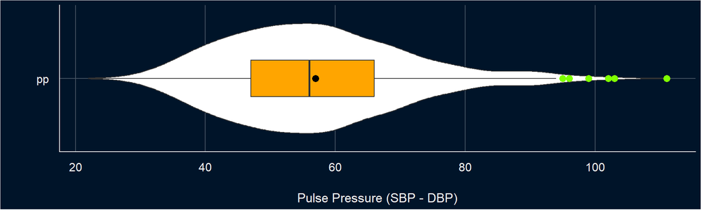

## Using `race` to predict `sbp` - `dbp`

- 700 subjects: 1 missing `sbp` & `dbp` plus 112 missing `race`.

```r
fit1 <- lm((sbp-dbp) ~ race, data = hbp700)
summary(fit1)
```

```
Call:
lm(formula = (sbp - dbp) ~ race, data = hbp700)

Residuals:
    Min      1Q  Median      3Q     Max
-28.191 -10.611  -1.611   8.809  53.809

Coefficients:
            Estimate Std. Error t value Pr(>|t|)
(Intercept)  57.1906     0.6882  83.104   <2e-16 ***
raceNHWhite  -1.5795     1.3100  -1.206    0.228
---
Signif. codes:  0 '***' 0.001 '**' 0.01 '*' 0.05 '.' 0.1 ' ' 1

Residual standard error: 14.19 on 585 degrees of freedom
  (113 observations deleted due to missingness)
Multiple R-squared:  0.002479,  Adjusted R-squared:  0.0007737
F-statistic: 1.454 on 1 and 585 DF,  p-value: 0.2284
```

## Assessing `fit1`

```r
n_obs(fit1)
```

```
[1] 587
```

```r
model_parameters(fit1, ci = 0.90, pretty_names = FALSE)
```

```
Parameter   | Coefficient |   SE |         90% CI | t(585) |      p
-------------------------------------------------------------------
(Intercept) |       57.19 | 0.69 | [56.06, 58.32] |  83.10 | < .001
raceNHWhite |       -1.58 | 1.31 | [-3.74,  0.58] |  -1.21 | 0.228
```

```r
model_performance(fit1)
```

```
# Indices of model performance

AIC    |   AICc |    BIC |    R2 | R2 (adj.) |   RMSE |  Sigma
--------------------------------------------------------------
4783.7 | 4783.7 | 4796.8 | 0.002 | 7.737e-04 | 14.163 | 14.187
```

## Add in age, as a covariate

```r
fit2 <- lm((sbp-dbp) ~ race + age, data = hbp700)
summary(fit2)
```

```
Call:
lm(formula = (sbp - dbp) ~ race + age, data = hbp700)

Residuals:
    Min      1Q  Median      3Q     Max
-29.297 -10.062  -1.709   7.953  53.321

Coefficients:
            Estimate Std. Error t value Pr(>|t|)
(Intercept) 36.32490    4.09642   8.867  < 2e-16 ***
raceNHWhite -2.03827    1.28523  -1.586    0.113
age          0.32355    0.06266   5.164 3.32e-07 ***
---
Signif. codes:  0 '***' 0.001 '**' 0.01 '*' 0.05 '.' 0.1 ' ' 1

Residual standard error: 13.89 on 584 degrees of freedom
  (113 observations deleted due to missingness)
Multiple R-squared:  0.04604,   Adjusted R-squared:  0.04277
F-statistic: 14.09 on 2 and 584 DF,  p-value: 1.055e-06
```

## Assessing `fit2`

```r
n_obs(fit2) # any more missingness?
```

```
[1] 587
```

```r
model_parameters(fit2, ci = 0.90, pretty_names = FALSE)
```

```
Parameter   | Coefficient |   SE |         90% CI | t(584) |      p
-------------------------------------------------------------------
(Intercept) |       36.32 | 4.10 | [29.58, 43.07] |   8.87 | < .001
raceNHWhite |       -2.04 | 1.29 | [-4.16,  0.08] |  -1.59 | 0.113
age         |        0.32 | 0.06 | [ 0.22,  0.43] |   5.16 | < .001
```

```r
model_performance(fit2)
```

```
# Indices of model performance

AIC    |   AICc |    BIC |    R2 | R2 (adj.) |   RMSE |  Sigma
--------------------------------------------------------------
4759.5 | 4759.5 | 4777.0 | 0.046 |     0.043 | 13.850 | 13.886
```

# Multiple Imputation: Potential and Pitfalls

## Sterne et al. 2009 *BMJ*

Multiple imputation for missing data in epidemiological and clinical research: potential and pitfalls

> In this article, we review the reasons why missing data may lead to bias and loss of information in epidemiological and clinical research. We discuss the circumstances in which multiple imputation may help by reducing bias or increasing precision, as well as describing potential pitfalls in its application. Finally, we describe the recent use and reporting of analyses using multiple imputation in general medical journals, and suggest guidelines for the conduct and reporting of such analyses.
- https://www.bmj.com/content/338/bmj.b2393

## An Example from Sterne et al.

Consider, for example, a study investigating the association of systolic blood pressure with the risk of subsequent coronary heart disease, in which data on systolic blood pressure are missing for some people.

The probability that systolic blood pressure is missing is likely to:

- decrease with age (doctors are more likely to measure it in older people),
- decrease with increasing body mass index, and
- decrease with history of smoking (doctors are more likely to measure it in people with heart disease risk factors or comorbidities).

If we assume that data are missing at random and that we have systolic blood pressure data on a representative sample of individuals within strata of age, smoking, body mass index, and coronary heart disease, then we can use multiple imputation to estimate the overall association between systolic blood pressure and coronary heart disease.

## Missing Data Mechanisms

- **Missing completely at random** There are no systematic differences between the missing values and the observed values.
  - For example, blood pressure measurements may be missing because of breakdown of an automatic sphygmomanometer.
- **Missing at random** Any systematic difference between the missing and observed values can be explained by other observed data.
  - For example, missing BP measurements may be lower than measured BPs but only because younger people more often have a missing BP.
- **Missing not at random** Even after the observed data are taken into account, systematic differences remain between the missing and the observed values.
  - For example, people with high BP may be more likely to have headaches that cause them to miss clinic appointments.

“Missing at random” is an **assumption** that justifies the analysis, and is not a property of the data.

## Trouble: Missing **not** at random

Sometimes, it is impossible to account for systematic differences between missing and observed values using the available data.

- In such (MNAR) cases, multiple imputation may give misleading results.
  - Those results can be either more or less misleading than a complete case analysis.
- For example, consider a study investigating predictors of depression.
  - If individuals are more likely to miss appointments because they are depressed on the day of the appointment, then it may be impossible to make the MAR assumption plausible, even if a large number of variables is included in the imputation model.

Where complete cases and multiple imputation analyses give different results, the analyst should attempt to understand why, and this should be reported in publications.

## What if the data are MCAR?

If we assume data are MAR, then unbiased and statistically more powerful analyses (compared with analyses based on complete cases) can generally be done by including individuals with incomplete data.

There are circumstances in which analyses of **complete cases** will not lead to bias.

- Missing data in predictor variables do not cause bias in analyses of complete cases if the reasons for the missing data are unrelated to the outcome.
  - In such cases, imputing missing data may lessen the loss of precision and power resulting from exclusion of individuals with incomplete predictor variables but are not required in order to avoid bias.

## Stages of Multiple Imputation (1/2)

> Multiple imputation … aims to allow for the uncertainty about the missing data by creating several different plausible imputed data sets and appropriately combining results obtained from each of them.

The first stage is to create multiple copies of the dataset, with the missing values replaced by imputed values.

- The imputation procedure must fully account for all uncertainty in predicting the missing values by injecting appropriate variability into the multiple imputed values; we can never know the true values of the missing data.

Note that single Imputation of missing values usually causes standard errors to be too small, since it fails to account for the fact that we are uncertain about the missing values.

## Stages of Multiple Imputation (2/2)

The second stage is to use standard statistical methods to fit the model of interest to each of the imputed datasets.

- Estimated associations in each of the imputed datasets will differ because of the variation introduced in the imputation of the missing values, and they are only useful when averaged together to give overall estimated associations.
- Standard errors are calculated using Rubin’s rules, which take account of the variability in results between the imputed datasets, reflecting the uncertainty associated with the missing values.
- Valid inferences are obtained because we are averaging over the distribution of the missing data given the observed data.

## Back to our little example

```r
fit1 <- lm(pp ~ race, data = hbp700)
fit2 <- lm(pp ~ race + age, data = hbp700)
```

How many subjects have complete / missing data affecting our models?

```r
hbp_sub <- hbp700 |> select(subject, sbp, dbp, pp, race, age)

hbp_sub |> pct_complete_case()
```

```
[1] 83.85714
```

```r
hbp_sub |> pct_miss_case()
```

```
[1] 16.14286
```

So how many imputations should we create?

## Building 20 imputations with `mice`

```r
set.seed(20251030)

hbp_mice20 <- mice(hbp_sub, m = 20, printFlag = FALSE)
```

Summary on next slide…

## Summarize Imputation Process

```r
summary(hbp_mice20)
```

```
Class: mids
Number of multiple imputations:  20
Imputation methods:
 subject      sbp      dbp       pp     race      age
      ""    "pmm"    "pmm"    "pmm" "logreg"       ""
PredictorMatrix:
        subject sbp dbp pp race age
subject       0   1   1  1    1   1
sbp           0   0   1  1    1   1
dbp           0   1   0  1    1   1
pp            0   1   1  0    1   1
race          0   1   1  1    0   1
age           0   1   1  1    1   0
Number of logged events:  101
  it im  dep     meth     out
1  0  0      constant subject
2  1  1 race   logreg     sbp
3  1  2 race   logreg     sbp
4  1  3 race   logreg     sbp
5  1  4 race   logreg     sbp
6  1  5 race   logreg     sbp
```

See Heymans and Eekhout sections 4.6 - 4.14 for more information.

## Imputation Options within `mice`

Default methods include:

- `pmm` predictive mean matching (default choice for quantitative variables)
- `logreg` logistic regression (default for binary categorical variables)
- `polyreg` polytomous logistic regression (for nominal multi-categorical variables)
- `polr` proportional odds logistic regression (for ordinal categories)

but there are `cart` methods and many others available, too.

## What should we include in an imputation model?

1. If things you are imputing are not Normally distributed, this can pose special challenges, and either a transformation or choosing an imputation method which is robust to these concerns is helpful.
2. Include the outcome when imputing predictors. It causes you to conclude the relationship is weaker than it actually is, if you don’t.
3. The MAR assumption may only be reasonable when a certain variable is included in the model.
   - As a result, it’s usually a good idea to include as wide a range of variables in imputation models as possible. The concerns we’d have about parsimony in outcome models don’t apply here.

## Store one imputed data set

This will store the fifth imputed data set in `imp_5`.

```r
imp_5 <- complete(hbp_mice20, 5) |> tibble()

dim(imp_5)
```

```
[1] 700   6
```

```r
n_miss(imp_5)
```

```
[1] 0
```

## Fit `fit2` on 5th imputation

```r
fit2_i5 <- lm((sbp-dbp) ~ race + age, data = imp_5)
summary(fit2_i5)
```

```
Call:
lm(formula = (sbp - dbp) ~ race + age, data = imp_5)

Residuals:
    Min      1Q  Median      3Q     Max
-35.319  -9.936  -1.709   7.775  53.353

Coefficients:
            Estimate Std. Error t value Pr(>|t|)
(Intercept) 35.99288    3.66028   9.833  < 2e-16 ***
raceNHWhite -1.97166    1.15970  -1.700   0.0895 .
age          0.32810    0.05534   5.929 4.79e-09 ***
---
Signif. codes:  0 '***' 0.001 '**' 0.01 '*' 0.05 '.' 0.1 ' ' 1

Residual standard error: 13.76 on 697 degrees of freedom
Multiple R-squared:  0.05011,   Adjusted R-squared:  0.04738
F-statistic: 18.38 on 2 and 697 DF,  p-value: 1.659e-08
```

## Assessing `fit2_i5`

```r
n_obs(fit2_i5) # any missingness?
```

```
[1] 700
```

```r
model_parameters(fit2_i5, ci = 0.90, pretty_names = FALSE)
```

```
Parameter   | Coefficient |   SE |         90% CI | t(697) |      p
-------------------------------------------------------------------
(Intercept) |       35.99 | 3.66 | [29.96, 42.02] |   9.83 | < .001
raceNHWhite |       -1.97 | 1.16 | [-3.88, -0.06] |  -1.70 | 0.090
age         |        0.33 | 0.06 | [ 0.24,  0.42] |   5.93 | < .001
```

```r
model_performance(fit2_i5)
```

```
# Indices of model performance

AIC    |   AICc |    BIC |    R2 | R2 (adj.) |   RMSE |  Sigma
--------------------------------------------------------------
5662.1 | 5662.1 | 5680.3 | 0.050 |     0.047 | 13.731 | 13.761
```

## Single imputation model check

```r
set.seed(431); check_model(fit2_i5, detrend = FALSE)
```

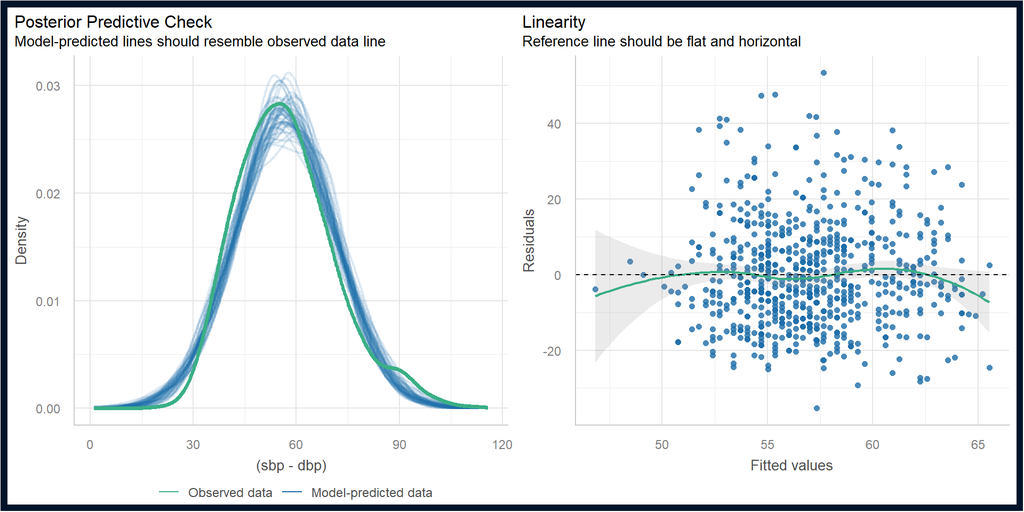

## Model check (next two plots)

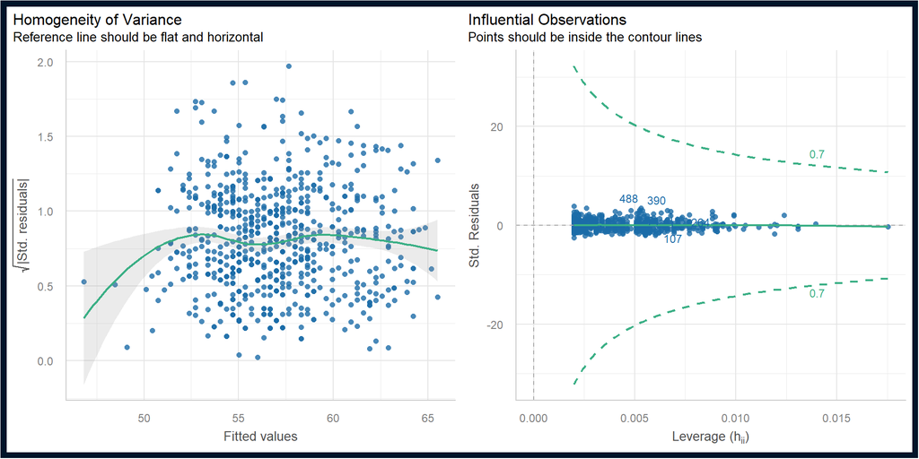

## Model check (final two plots)

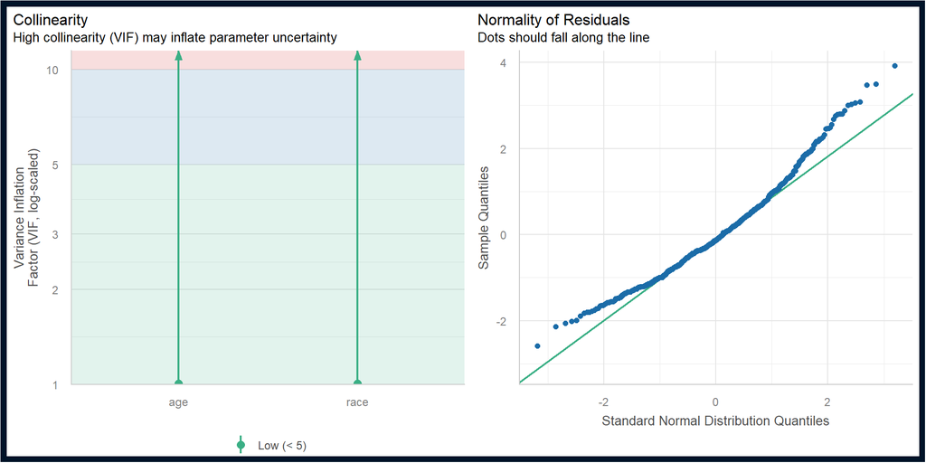

## Collinearity Checks

- **Collinearity** (also called multicollinearity) happens when some predictors in a model are highly correlated with each other. This can de-stabilize our model estimates.

```r
check_collinearity(fit2_i5)
```

```
# Check for Multicollinearity

Low Correlation

 Term  VIF      VIF 95% CI adj. VIF Tolerance Tolerance 95% CI
 race 1.01 [1.00, 5403.32]     1.00      0.99     [0.00, 1.00]
  age 1.01 [1.00, 5403.32]     1.00      0.99     [0.00, 1.00]
```

## Variance Inflation Factor (VIF)

- **Variance Inflation Factor** (VIF) will begin to concern us when it exceeds 5.
- VIF measures how much the variance of a regression coefficient is increased due to correlation between multiple predictors in the model.
- If we have a high VIF, we consider either dropping predictors or changing how the concepts they represent are included.
  - Example: height and weight have high VIF, switch to height and waist circumference?

## `fit2` on each imputed data frame

3 coefficient estimates times 20 imputed sets = 60 rows.

```r
m2_mods <- with(hbp_mice20, lm(pp ~ race + age))

summary(m2_mods)
```

```
# A tibble: 60 × 7
   term        estimate std.error statistic  p.value  nobs df.residual
   <chr>          <dbl>     <dbl>     <dbl>    <dbl> <int>       <dbl>
 1 (Intercept)   36.0      3.66        9.84 1.75e-21   700         697
 2 raceNHWhite   -2.51     1.17       -2.15 3.18e- 2   700         697
 3 age            0.330    0.0552      5.97 3.69e- 9   700         697
 4 (Intercept)   35.9      3.66        9.81 2.20e-21   700         697
 5 raceNHWhite   -1.82     1.15       -1.59 1.12e- 1   700         697
 6 age            0.329    0.0555      5.93 4.89e- 9   700         697
 7 (Intercept)   36.1      3.66        9.86 1.51e-21   700         697
 8 raceNHWhite   -2.11     1.16       -1.82 6.89e- 2   700         697
 9 age            0.327    0.0552      5.92 5.06e- 9   700         697
10 (Intercept)   36.1      3.67        9.85 1.62e-21   700         697
# ℹ 50 more rows
```

## Pool across the 20 imputations

```r
m2_pool <- pool(m2_mods)

n_obs(m2_pool)
```

```
 [1] 700 700 700 700 700 700 700 700 700 700 700 700 700 700 700 700 700 700 700
[20] 700
```

```r
model_parameters(m2_pool, ci = 0.90, pretty_names = FALSE)
```

```
# Fixed Effects

Parameter   | Coefficient |   SE |         90% CI |     t |     df |      p
---------------------------------------------------------------------------
(Intercept) |       36.00 | 3.67 | [29.97, 42.04] |  9.82 | 694.05 | < .001
raceNHWhite |       -2.00 | 1.21 | [-4.00, -0.01] | -1.65 | 530.87 | 0.099
age         |        0.33 | 0.06 | [ 0.24,  0.42] |  5.92 | 693.69 | < .001
```

## Compare to our original `fit2`

```r
n_obs(fit2)
```

```
[1] 587
```

```r
## no imputation
model_parameters(fit2, ci = 0.90, pretty_names = FALSE)
```

```
Parameter   | Coefficient |   SE |         90% CI | t(584) |      p
-------------------------------------------------------------------
(Intercept) |       36.32 | 4.10 | [29.58, 43.07] |   8.87 | < .001
raceNHWhite |       -2.04 | 1.29 | [-4.16,  0.08] |  -1.59 | 0.113
age         |        0.32 | 0.06 | [ 0.22,  0.43] |   5.16 | < .001
```

```r
## multiple imputation
model_parameters(m2_pool, ci = 0.90, pretty_names = FALSE)
```

```
# Fixed Effects

Parameter   | Coefficient |   SE |         90% CI |     t |     df |      p
---------------------------------------------------------------------------
(Intercept) |       36.00 | 3.67 | [29.97, 42.04] |  9.82 | 694.05 | < .001
raceNHWhite |       -2.00 | 1.21 | [-4.00, -0.01] | -1.65 | 530.87 | 0.099
age         |        0.33 | 0.06 | [ 0.24,  0.42] |  5.92 | 693.69 | < .001
```

## Estimate $R^2$ and Adjusted $R^2$

```r
pool.r.squared(m2_mods)
```

```
           est      lo 95      hi 95         fmi
R^2 0.05026683 0.02320666 0.08626531 0.008149325
```

```r
pool.r.squared(m2_mods, adjusted = TRUE)
```

```
               est     lo 95      hi 95         fmi
adj R^2 0.04754104 0.0213113 0.08282485 0.008617821
```

```r
model_performance(fit2) # original model with NAs
```

```
# Indices of model performance

AIC    |   AICc |    BIC |    R2 | R2 (adj.) |   RMSE |  Sigma
--------------------------------------------------------------
4759.5 | 4759.5 | 4777.0 | 0.046 |     0.043 | 13.850 | 13.886
```

More to come. See [Chapter 17 of our Course Book](https://thomaselove.github.io/431-book/17_adjtrans.html) for more discussion and an additional example.